# Bayesian Modeling Problem Set 1

```r
#The sample mean approaches the population mean slower with a higher initial fluctuation from the population mean
```

7. How would your line of means look if the standard deviation of the population was smaller? Repeat steps 1–3 for a standard deviation of 5. Save this vector of means as `mean3`.

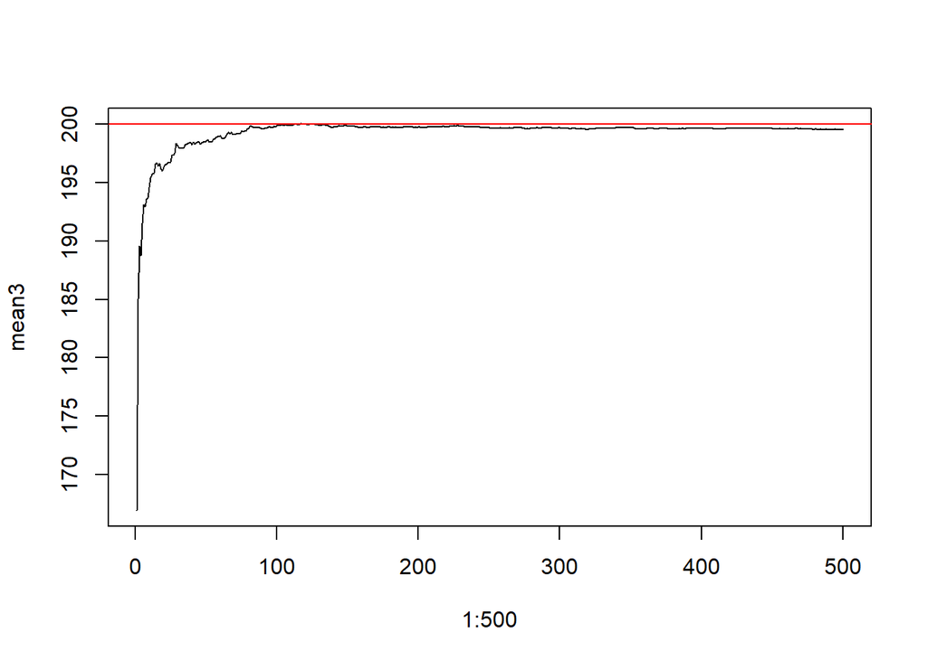

```r
SD_Y_3=5 #setting a smaller standard deviation
Y_3=rnorm(1,mean=E_Y,sd=SD_Y_2)
mean3=rep(NA,500)
mean3[1]=Y_3
for (i in 2:500){
  Y_3=c(Y_3,rnorm(1,mean=E_Y,sd=SD_Y_3))
  mean3[i]=mean(Y_3)
}
plot(x=1:500,mean3,type="l")
abline(h=E_Y,col="red")
```

```r
##The sample mean approaches the population mean much faster with a lower initial fluctuation from the population mean
```

8. Create a single, clear and attractive plot that shows the true population mean and sample means given the three standard deviations. Make sure your mean lines are distinguishable and labeled (e.g., with `legend()`).

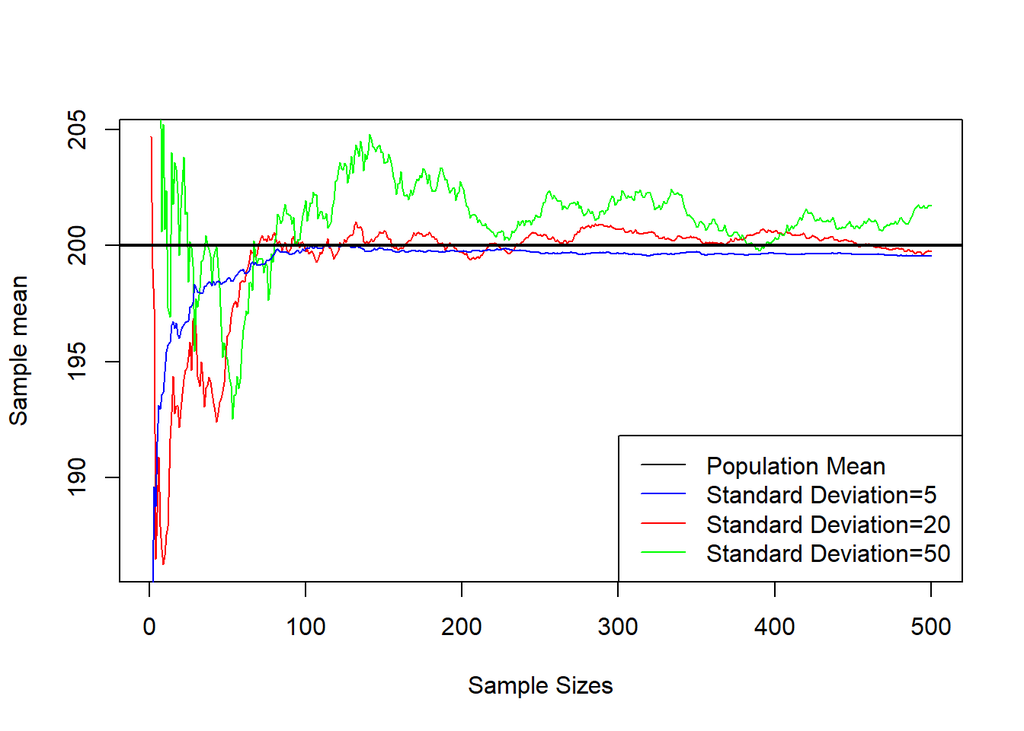

```r
plot(1:500, mean1, type = "l", col = "red", xlab = "Sample Sizes", ylab = "Sample mean")
lines(1:500, mean2, col = "green")
lines(1:500, mean3, col = "blue")
abline(h=E_Y,col="black",lwd=2)
legend("bottomright", legend = c("Population Mean","Standard Deviation=5", "Standard Deviation=20", "Standard Deviation=50"),col = c("black","blue","red", "green" ), lty = 1,lwd=1)
```

9. Briefly summarize what we can learn from your plot in 8. What is the relationship between variability in a population and the sample size necessary to accurately estimate the population mean?

```r
#As the variability in a population increases, the sample size necessary to accurately estimate the population mean increase. As demonstrated in the figure in 8,with standard deviation increases from 5 to 50, the sample mean approaches close to population mean roughly at the sample sizes of 150, 450 and >500 respectively.
```

10. Above, we have illustrated the Law of Large Numbers for a Gaussian distribution, where the expected value is equal to the mean. But what about for other distributions? Repeat steps 1-4 for a Poisson distribution where $\lambda=200$ and for a Gamma distribution with shape = 200 and scale = 1. For both cases, the expected value is still 200.

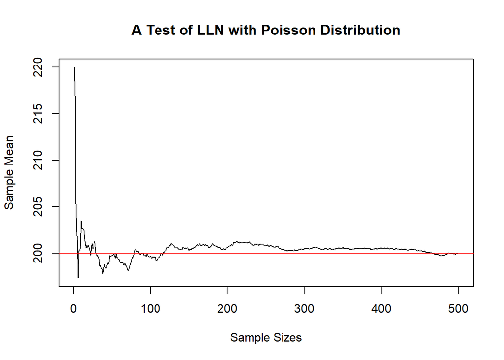

```r
poisson_lambda_Y=200
Y_pois=rpois(1,lambda=poisson_lambda_Y)
mean_pois=rep(NA,500)
mean_pois[1]=Y_pois
for (i in 2:500){
  Y_pois=c(Y_pois,rpois(1,lambda=poisson_lambda_Y))
  mean_pois[i]=mean(Y_pois)
}
plot(x=1:500,mean_pois,type="l",xlab = "Sample Sizes", ylab = "Sample Mean",main="A Test of LLN with Poisson Distribution")
abline(h=E_Y,col="red")#
```